# Domača naloga 4

Osnove teoretične statistike

Alen Kahteran

24. 01. 2020

# Točka 1

## a)

Vemo za naslednje stvari

$$f_X(x) = \frac{\beta^\alpha}{\Gamma(\alpha)}x^{\alpha-1}e^{-\beta x}\ \ \ \ \ \mathrm{za}\ \ x>0$$
$$Y = \frac{1}{X}\ \ \ \ \ \mathrm{oz.}\ \ Y=g(x) = 1/x$$

$$f_Y(y)=f_X(g^{-1}(y))\left\lvert\frac{d}{dy}g^{-1}(y)\right\rvert$$

Potrebujemo torej $g^{-1}(y)$.

$$g(x) = \frac{1}{x}$$
$$y=\frac{1}{x}$$
nekoliko obrnemo

$$x=\frac{1}{y}$$

se pravi

$$g^{-1}(y) = \frac{1}{y}$$

Ustavimo v enačbo za $f_y(y)$

$$f_Y(y)=f_X\left(\frac{1}{y}\right)\left\lvert\frac{d}{dy}\frac{1}{y}\right\rvert$$
Odvod $\frac{1}{y}$ po $y$ je enak $\frac{-1}{y^2}$ medtem ko je $f_X(1/y)$ enako

$$f_X\left(\frac{1}{y}\right) = \frac{\beta^\alpha}{\Gamma(\alpha)}\frac{1}{y^{\alpha-1}}e^{\frac{-\beta}{y}}$$

Torej dobimo

$$f_Y(y)=\frac{\beta^\alpha}{\Gamma(\alpha)}\frac{1}{y^{\alpha-1}}e^{\frac{-\beta}{y}}\left\lvert\frac{-1}{y^2}\right\rvert$$
če nekoliko stvari pokrajšamo dobimo

$$f_Y(y)=\frac{\beta^\alpha}{\Gamma(\alpha)}\frac{1}{y^{\alpha+1}}e^{\frac{-\beta}{y}}$$

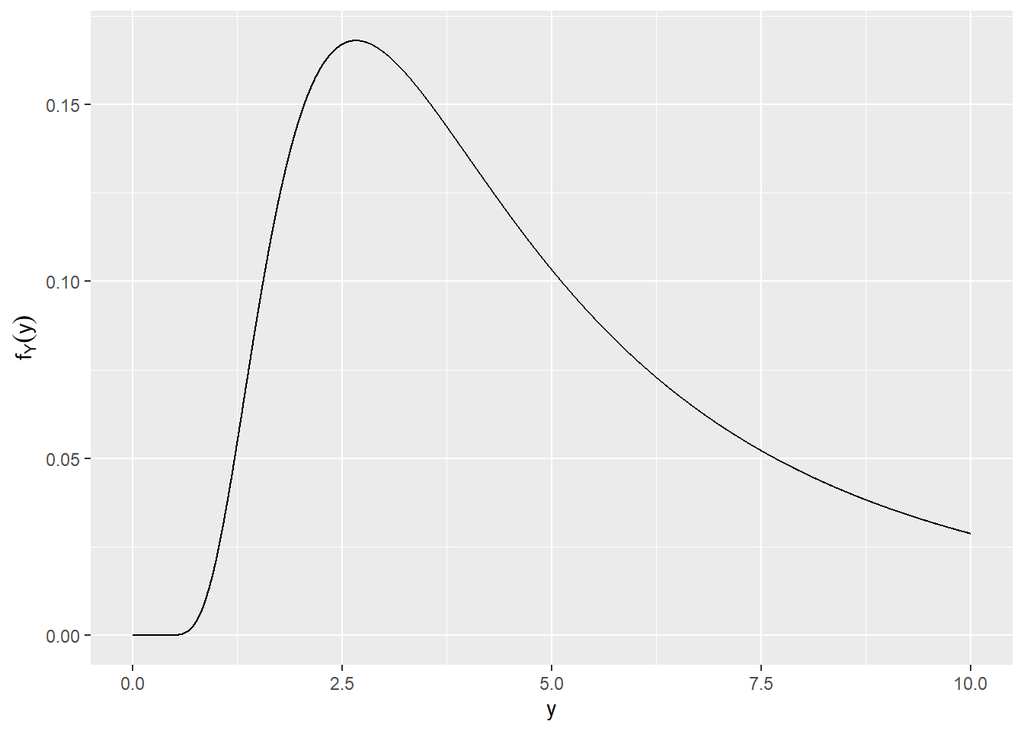

```r
# setting seed for reproducibility
set.seed(8)

# selectin alpha and beta for drawing purposes
alpha <- 2
beta <- 8

# generating y value
y <- seq(from=0, to=10, by=0.001)

# calculating fy (NaN at y=0)
fy <- ((beta^alpha) / gamma(alpha)) * (1/(y^(alpha + 1))) * exp(-beta/y)

ggplot(mapping=aes(x=y, y=fy)) +
    geom_line() +
    labs(x="y",
         y=expression(f[Y](y)))
```

Definicijsko območje je $D_{f_Y} = (0,\infty)$ (ko govorimo o gostoti, seveda). Da je zvezna funkcija lahko gostota zvezne spremenljivke mora veljati da je njen integral po definicijskem območju enak $1$.

## b)

$$E[Y] = \int_{-\infty}^{\infty}y\cdot f_Y(y)\ dy$$

ker je ta definirana le na območju $(0,\infty)$ lahko zapišemo tudi kot

$$E[Y] = \int_{0}^{\infty}y\cdot f_Y(y)\ dy$$
Če ustavimo še $f_Y(y)$ dobimo

$$E[Y] = \int_{0}^{\infty}y\cdot \frac{\beta^\alpha}{\Gamma(\alpha)}\frac{1}{y^{\alpha+1}}e^{\frac{-\beta}{y}}\ dy$$
Najprej pokrajšajmo $y$

$$E[Y] = \int_{0}^{\infty}\frac{\beta^\alpha}{\Gamma(\alpha)}\frac{1}{y^{\alpha}}e^{\frac{-\beta}{y}}\ dy$$
Nekoliko preoblikujmo, da dobimo inverzno gamma funkcijo za katero vemo da je integral enak $1$.

$$E[Y] = \int_{0}^{\infty}\frac{\beta}{\alpha - 1}\frac{\beta^{\alpha-1}}{\Gamma(\alpha -1)}\frac{1}{y^{\alpha}}e^{\frac{-\beta}{y}}\ dy$$

$\frac{\beta}{\alpha - 1}$ nesemo ven iz integrala ker je konstanta.

$$E[Y] = \frac{\beta}{\alpha - 1} \int_{0}^{\infty}\frac{\beta^{\alpha-1}}{\Gamma(\alpha -1)}\frac{1}{y^{\alpha}}e^{\frac{-\beta}{y}}\ dy$$
za ta integral pa vemo da je enak inverzni gamma funkciji katere integral je enak $1$ (z različnimi koeficienti lahko vidimo že v prejšnjem delu naloge). Torej pričakovana vrednost $Y$ je

$$E[Y] = \frac{\beta}{\alpha - 1} \cdot 1 = \frac{\beta}{\alpha - 1}$$

# Točka 2

## a)

Poznamo $\alpha=2$, vemo da $\Gamma(2) = 1$ in če stvari ustavimo in polepšamo lahko gostoto za Y zapišemo kot

$$f_Y(y)=\frac{\beta^2}{y^{3}}e^{\frac{-\beta}{y}}$$

Z metodo največjega verjetja ocenjujemo $\beta$. Vstavimo v enačbo torej

$$L(y,\alpha=2, \beta) = \prod_{i=1}^n\frac{\beta^2}{y_i^{3}}e^{\frac{-\beta}{y_i}}$$

Preden logaritmiramo, dajmo to enačbo zapisati v obliki s katero je lažje računati

$$L(y,\alpha=2, \beta) = \prod_{i=1}^n\beta^2 y_i^{-3}e^{\frac{-\beta}{y_i}}$$
Sedaj logaritmirajmo

$$\ln(L(y,\alpha=2, \beta)) = \sum_{i=1}^n \ln(\beta^2)+\ln(y_i^{-3})-\frac{\beta}{y_i}$$
Potence nesemo ven iz logaritmov

$$\ln(L(y,\alpha=2, \beta)) = \sum_{i=1}^n\left( 2\ln(\beta)-3\ln(y_i)-\frac{\beta}{y_i}\right)$$

Glede na to da nas zanima cenilka za $\beta$ parcialno odvajajmo po $\beta$

$$\frac{\partial\ln(L(y,\alpha=2, \beta))}{\partial\beta} = \sum_{i=1}^n\left( \frac{2}{\beta}-\frac{1}{y_i}\right)$$
$\frac{2}{\beta}$ lahko nesemo ven iz vsote (pomnoženo z $n$)

$$\frac{\partial\ln(L(y,\alpha=2, \beta))}{\partial\beta} = \frac{2}{\beta}n-\sum_{i=1}^n\frac{1}{y_i}$$
Najboljša cenilka za $\beta$ je takrat ko je ta odvod enak 0 tj.

$$\frac{\partial\ln(L(y,\alpha=2, \beta))}{\partial\beta} = 0$$
Oz.

$$0 = \frac{2n}{\hat{\beta}}-\sum_{i=1}^n\frac{1}{y_i}$$
ali pa še lepše

$$\frac{2n}{\hat{\beta}} = \sum_{i=1}^n\frac{1}{y_i}$$
Obrnimo še enačbo in dobimo

$$\hat{\beta} = \frac{2n}{\sum_{i=1}^n\frac{1}{y_i}}$$

## b)

Zanima nas ali je cenilka nepristranska. Zapišimo torej našo cenilko.

$$E[\hat{\beta}] = E\left[\frac{2n}{\sum_{i=1}^n\frac{1}{y_i}}\right]$$

Prek Jensenove neenakosti lahko zapišemo naslednje (funkcija je $1/x$, ki je konveksna funkcija za $x>0$)

$$E\left[\frac{2n}{\sum_{i=1}^n\frac{1}{y_i}}\right] > \frac{2n}{E\left[\sum_{i=1}^n\frac{1}{y_i}\right]}$$

desni del enačbe lahko zapišemo kot

$$\frac{2n}{E\left[\sum_{i=1}^n\frac{1}{y_i}\right]} = \frac{2n}{E\left[n\cdot\frac{1}{n}\sum_{i=1}^n\frac{1}{y_i}\right]}$$
za $\frac{1}{n}\sum_{i=1}^n\frac{1}{y_i}$ pa vemo da je porazdeljena po gama porazdelitvi ki ima pričakovano vrednost $\alpha/\beta$. Torej, če nesemo najprej $n$ ven iz pričakovane vrednosti, in potem upoštevamo omenjeno prej, dobimo naslednje

$$E\left[\frac{2n}{\sum_{i=1}^n\frac{1}{y_i}}\right] > \frac{2n}{n\cdot\frac{\alpha}{\beta}}$$

Če upoštevamo da $\alpha=2$ in nato nekoliko obrnemo enačbo dobimo

$$E\left[\frac{2n}{\sum_{i=1}^n\frac{1}{y_i}}\right] > \frac{2n\cdot\beta}{2n}$$
in posledično

$$E\left[\frac{2n}{\sum_{i=1}^n\frac{1}{y_i}}\right] > \beta$$
oz.

$$E\left[\hat{\beta}\right] > \beta$$

```r
n <- 9

beta_hats <- replicate(10000, 2*n / (sum(1/(rgamma(n=n, alpha, beta)^-1))))

mean(beta_hats)
```

```
## [1] 8.457849
```

## c)

Vemo da

$$Var(\beta) = \frac{1}{n}I^{-1}(\beta)$$
in

$$I(\beta) = - E\left[\frac{\partial^2\ln(f_Y(y))}{\partial\beta^2}\right]$$
za $\alpha=2$ vemo da je $f_Y(y)$ enak

$$f_Y(y) = \frac{\beta^2}{y^{3}}e^{\frac{-\beta}{y}}$$
naravni logaritem tega pa

$$\ln(f_Y(y))=2\ln(\beta)-3\ln(y)-\frac{\beta}{y}$$

Prvi in drugi odvod tega logaritma po $\beta$ sta

$$\frac{\partial\ln(f_Y(y))}{\partial\beta} = \frac{2}{\beta} - \frac{1}{y}$$

$$\frac{\partial^2\ln(f_Y(y))}{\partial\beta^2} = -\frac{2}{\beta^2}$$

Če sedaj vse skupaj damo v prvotno enačbo dobimo

$$Var(\hat{\beta}) = \frac{\beta^2}{2n}$$

Interval zaupanja za $\beta$ je pa

$$\frac{2n}{\sum_{i=1}^n\frac{1}{y_i}} \pm z_{\alpha/2}\cdot \sqrt{\frac{\hat{\beta}^2}{2n}}$$

## d)

Vemo da je asimptotska porazdelitev $\sqrt{n}(\hat{\beta} - \beta_0)$ enaka $N(0, I^{-1}(\beta_0))$. Predkratkim smo izračunali nekaj podobnega in zato vemo da je

$$I^{-1}(\beta_0) = \frac{\beta_0^2}{2}$$
in potemtakem velja da je asimptotska porazdelitev enaka

$$N\left(0, \frac{\beta_0^2}{2}\right)$$

Za $n$ sem si izbral vrednost $100000$ (mora biti dovolj velika da velja asimptotsko), za št. ponovitev pa $1000$. Parametra gama funkcije ostaneta enaka kot v prejšnjih primerih ($\alpha = 2$ in $\beta$ oz. $\beta_0 = 8$). Poleg je dodana še normalna porazdelitev ($N\left(0, \frac{\beta_0^2}{2}\right)$ oz. $N\left(0, 32\right)$).

```r
n <- 100000
iter <- 1000
alpha <- 2
beta <- 8

set.seed(9)
tmp <- sqrt(n) * (replicate(iter, 2*n / (sum(1/(rgamma(n=n, alpha, beta)^-1)))) - beta)

var(tmp)
```

```
## [1] 31.78362
```

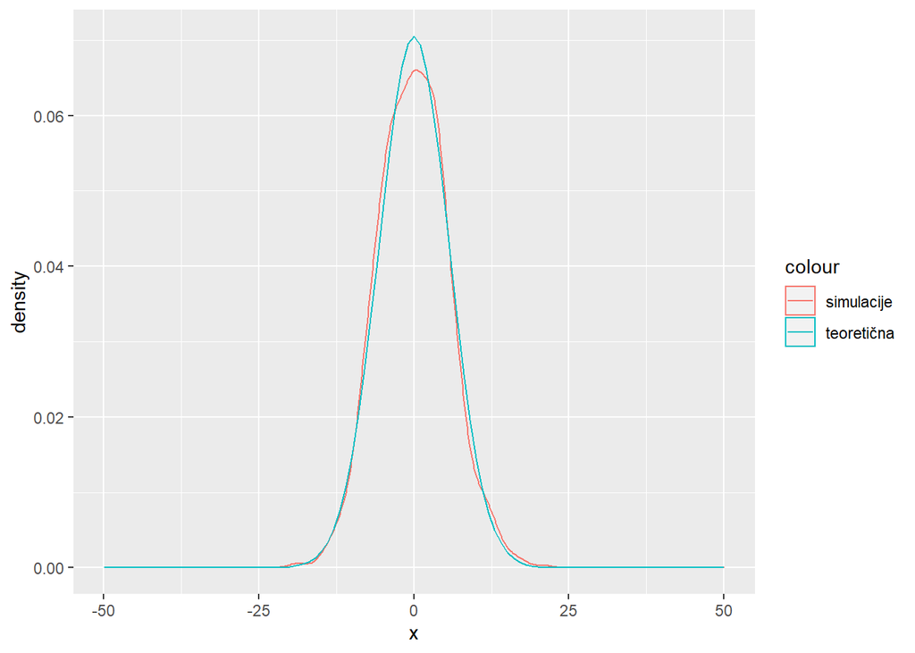

```r
ggplot(data.frame(x=tmp, funx=seq(-49.9, 50, 0.1))) +
    geom_density(aes(x=x, color="simulacije")) +
    stat_function(fun=dnorm,
                  geom="line",
                  args=list(mean=0, sd=sqrt(32)),
                  aes(x=funx, color="teoretična"))
```

Vidimo da se variance približno ujemata (razumljivo da je nekaj odstopanja zaradi le $1000$ ponovitev), ravno tako je vizualno videti na sliki da drži.

## d)

Za metodo delta velja

$$Var(g(\hat{\theta})) = g'(\theta_0)^2\ Var(\hat{\theta})$$

$\hat{\theta}$ v našem primeru predstavlja

$$\hat{\theta} = \frac{1}{n} \sum_{i=1}^n\frac{1}{y_i}=\frac{1}{n} \sum_{i=1}^ngamma(2,\beta)$$

$Var(\hat{\theta})$ pa

$$Var(\hat{\theta}) = \frac{1}{n}\ Var(gamma(2,\beta))$$
kjer vemo da $Var(gamma(2,\beta))$ je enako

$$Var(gamma(2,\beta) = \frac{2}{\beta^2}$$

Torej lahko zapišemo $Var(\hat{\theta})$ kot

$$Var(\hat{\theta}) = \frac{1}{n}\cdot \frac{2}{\beta^2} = \frac{2}{n\beta^2}$$

Veljajo še naslednje enačbe

$$g(\theta) = \frac{2}{\theta}$$

$$g'(\theta) = -\frac{2}{\theta^2}$$

$$(g'(\theta))^2 = \frac{4}{\theta^4}$$

S tem lahko zapišmo da je $Var(\hat{\beta})$ enak